# iPSC clustering and cell cycle phase matching

Kushal K Dey, Joyce H. Siao

July 13, 2015

The main focus of this script is to perform a clustering of iPSC using Structure and then trying to figure out if that clustering corresponds to the cell cycle phases as obtained by John Blischak. We first use his code to filter out the data set for both reads and molecules so as to remove the “drop-outs” cells and genes that are not expressed.

- read the reads and molecules files

```r
#setwd('/Users/kushal/Documents/Matthew Stephens Project/counts_clustering/Single_Cell_seq_Blischak/src/');
reads <- data.frame(fread('../data/reads.txt'),row.names=1);
molecules <-  data.frame(fread('../data/molecules.txt'),row.names=1);
```

- read the quality check file and the annotation file

```r
quality_single_cells <- scan("../data/quality-single-cells.txt",
                             what = "character")

anno <- data.frame(fread('../data/annotation.txt'));
```

- Removing the non single cells or bulk data

```r
molecules <- molecules[, grepl("bulk", colnames(molecules)) |
                         colnames(molecules) %in% quality_single_cells]
anno <- anno[anno$well == "bulk" | anno$sample_id %in% quality_single_cells, ]
stopifnot(ncol(molecules) == nrow(anno),
          colnames(molecules) == anno$sample_id)

reads <- reads[, grepl("bulk", colnames(reads)) |
                         colnames(reads) %in% quality_single_cells]
stopifnot(ncol(reads) == nrow(anno),
          colnames(reads) == anno$sample_id)
```

- Filtering out gens with zero counts in single cells/ bulk.

```r
expressed <- rowSums(molecules[, anno$well == "bulk"]) > 0 &
             rowSums(molecules[, anno$well != "bulk"]) > 0
molecules <- molecules[expressed, ]
dim(molecules)
```

```
## [1] 17153   587
```

```r
expressed <- rowSums(reads[, anno$well == "bulk"]) > 0 &
             rowSums(reads[, anno$well != "bulk"]) > 0
reads <- reads[expressed, ]
dim(reads)
```

```
## [1] 17162   587
```

```r
molecules_single <- molecules %>% select(-contains("bulk"))
reads_single <- reads %>% select(-contains("bulk"))

## Remove genes with max molecule numer larger than 1024

molecules_single <- molecules_single[apply(molecules_single,1,max) < 1024,];
```

- Obtain cell cycle information for the genes

```r
cell_cycle_genes <- read.table("../data/cellcyclegenes.txt", header = TRUE, sep="\t")

## create 5 lists of 5 phases (de-level and then remove "")
cell_cycle_genes_list <- lapply(1:5,function(x){
  temp <- as.character(cell_cycle_genes[,x])
  temp[temp!=""]
})
```

- Obtain phase scores for each sample

```r
ans <-
sapply(cell_cycle_genes_list,function(xx){
  #### create table of each phase
  reads_single_phase <- reads_single[rownames(reads_single) %in% unlist(xx) ,]
  #### add average expression of all genes in the phase
  combined_matrix <- rbind(reads_single_phase,average=apply(reads_single_phase,2,mean))
  #### use transpose to compute cor matrix
  cor_matrix <- cor(t(combined_matrix))
  #### take the numbers
  cor_vector <- cor_matrix[,dim(cor_matrix)[1]]
  #### restrict to correlation >= 0.3
  reads_single_phase_restricted <- reads_single_phase[rownames(reads_single_phase) %in% names(cor_vector[cor_vector >= 0.3]),]
  #### apply normalization to reads
  norm_factors_single <- calcNormFactors(reads_single_phase_restricted, method = "TMM")
  reads_single_cpm <- cpm(reads_single_phase_restricted, log = TRUE,
                            lib.size = colSums(reads_single) * norm_factors_single)
  #### output the phase specific scores (mean of normalized expression levels in the phase)
  apply(reads_single_cpm,2,mean)

})

head(ans)
```

```
##                   [,1]     [,2]     [,3]     [,4]     [,5]
## NA19098.1.A01 6.155267 5.792305 4.765538 5.263269 7.369384
## NA19098.1.A02 6.708742 5.997631 5.422098 5.699212 7.579759
## NA19098.1.A04 7.006426 5.932785 5.136685 5.351807 7.282850
## NA19098.1.A05 7.265333 6.942455 5.626944 5.667291 7.806992
## NA19098.1.A06 6.519006 7.043136 5.871448 6.564793 7.839005
## NA19098.1.A07 7.293232 6.441728 5.278741 5.859825 7.910691
```

- Two step normalization of phase-specific scores

```r
#### normalization function
flexible_normalization <- function(data_in,by_row=TRUE){
  if(by_row){
    row_mean <- apply(data_in,1,mean)
    row_sd   <- apply(data_in,1,sd)
    output <- data_in
    for(i in 1:dim(data_in)[1]){
      output[i,] <- (data_in[i,] - row_mean[i])/row_sd[i]
    }
  }
  #### if by column
  if(!by_row){
    col_mean <- apply(data_in,2,mean)
    col_sd   <- apply(data_in,2,sd)
    output <- data_in
    for(i in 1:dim(data_in)[2]){
      output[,i] <- (data_in[,i] - col_mean[i])/col_sd[i]
    }
  }
  output
}

#### apply the normalization function
## first normalized for each phase
ans_normed <- flexible_normalization(ans,by_row=FALSE)
## then normalized of each cell
ans_normed_normed <- flexible_normalization(ans_normed,by_row=TRUE)

head(ans_normed_normed)
```

```
##                     [,1]       [,2]        [,3]       [,4]       [,5]
## NA19098.1.A01 -0.3262157 -1.4409587  0.03916029  0.4623409  1.2656732
## NA19098.1.A02  0.4918844 -1.7310708  0.29152189  0.1366198  0.8110447
## NA19098.1.A04  1.5958650 -1.1564608  0.03792638 -0.2236197 -0.2537109
## NA19098.1.A05  1.0606821  0.4971184 -0.67721777 -1.3840842  0.5035016
## NA19098.1.A06 -1.6641325  0.7088810 -0.20733125  0.6497215  0.5128612
## NA19098.1.A07  1.1268014 -0.8172365 -0.89233368 -0.4490121  1.0317809
```

- Assign cell phase for each cell

```r
cell_phase <- apply(ans_normed_normed,1,function(x) colnames(cell_cycle_genes)[which.max(x)])
assign_cell_phase <- data.frame(cell_phase)
```

We check from here on if these cell phases show up in the Structure clustering.

## Cell cycle effects (reads)

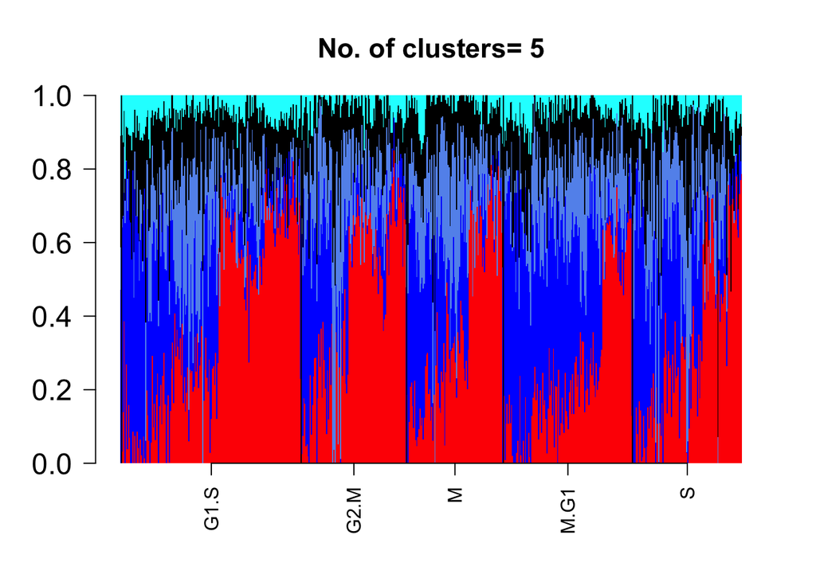

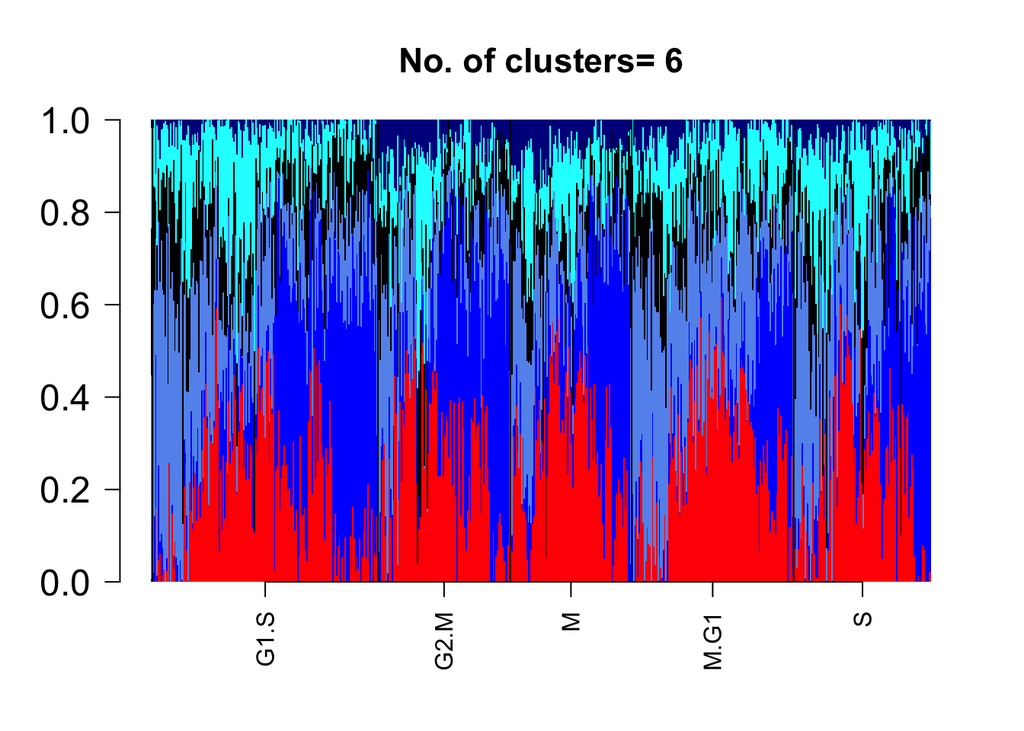

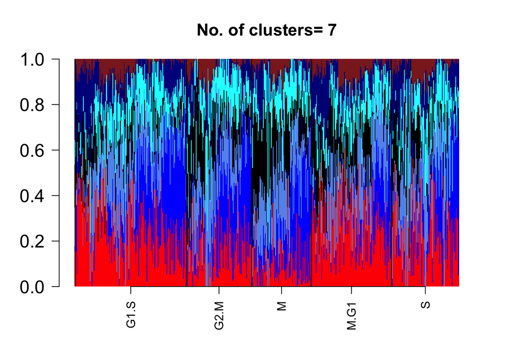

## Individual effects (reads)

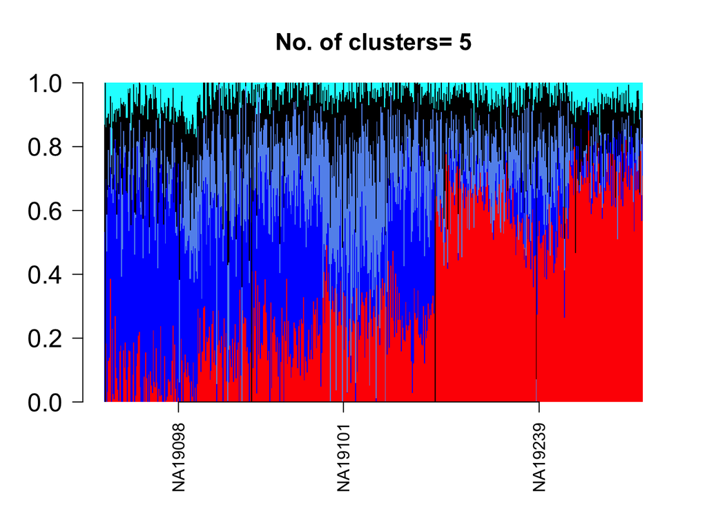

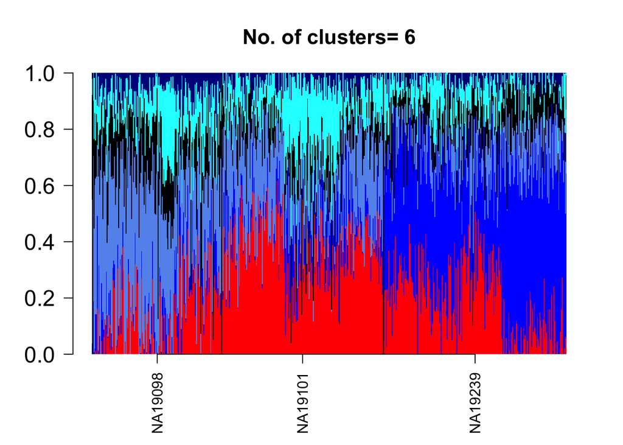

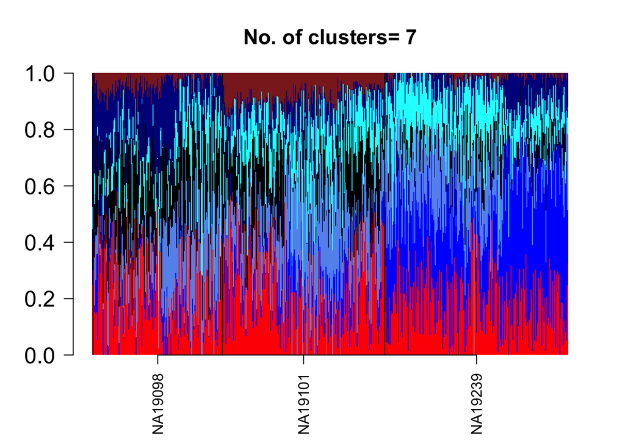

## Batch effects (reads)

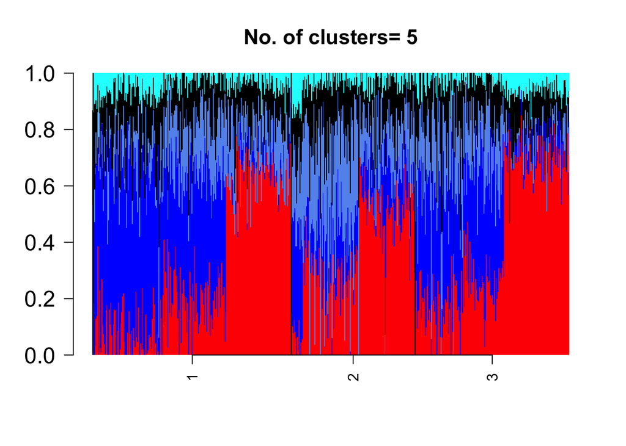

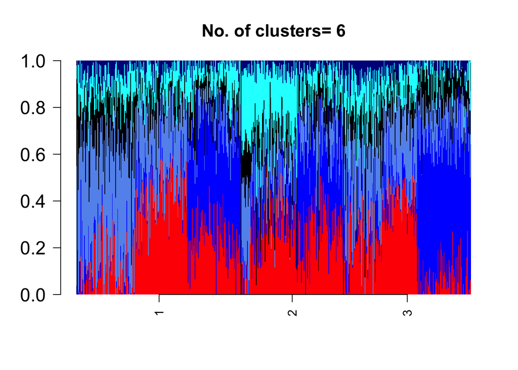

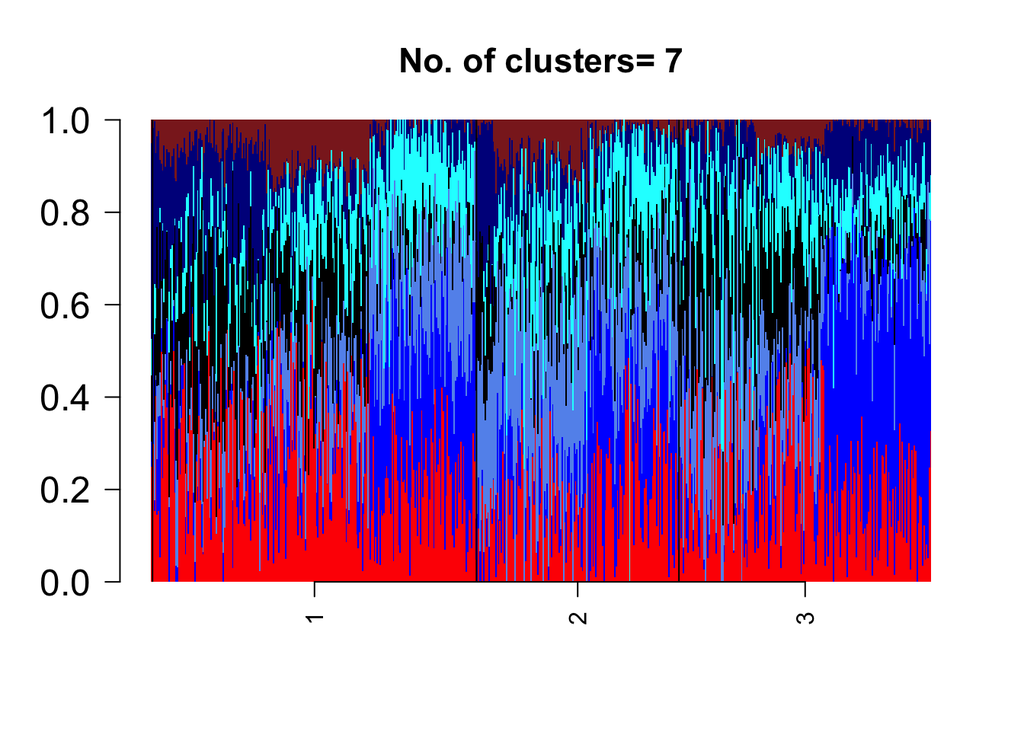

## Well effect (reads)

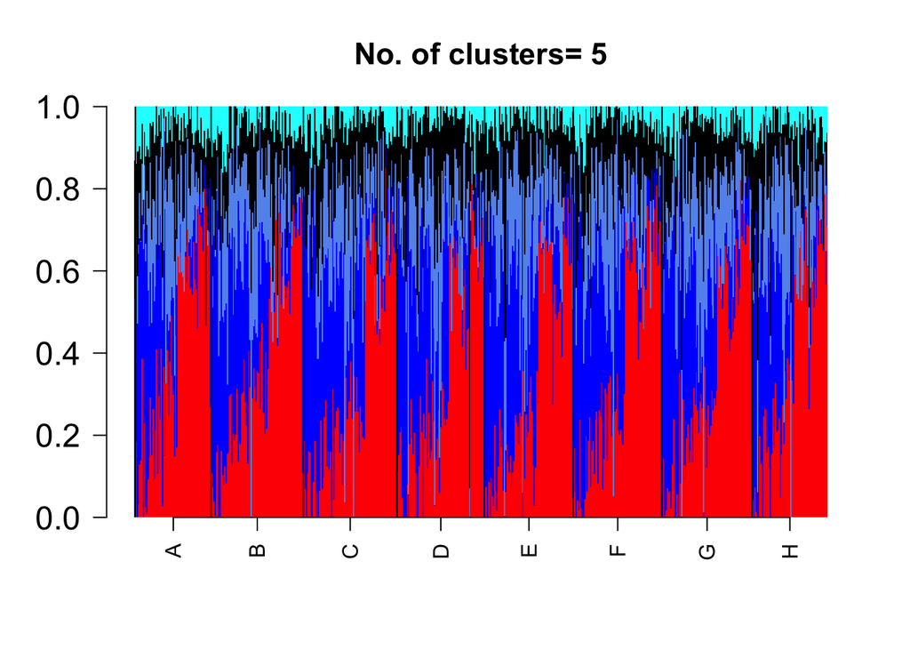

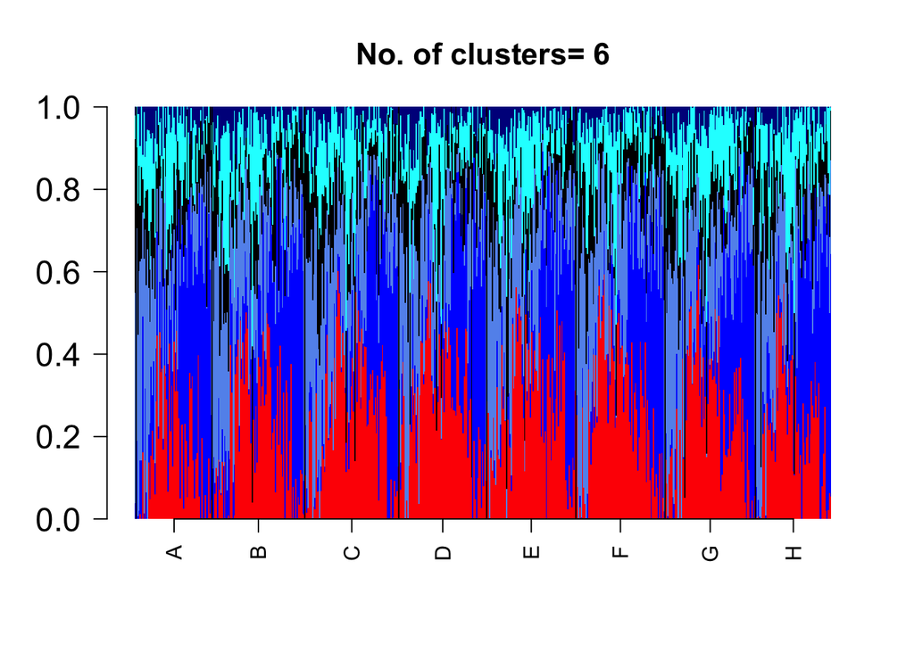

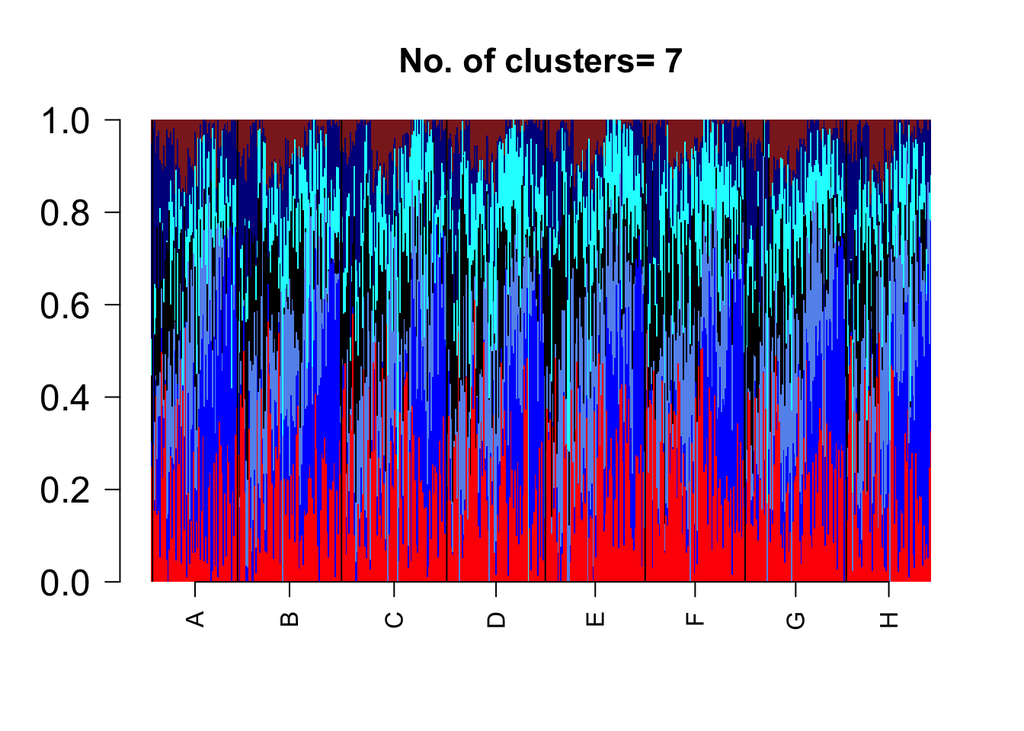

# Molecules Data

Above we focused only on the reads data. In this section, we shall focus on the molecules data which is the set of reads that were tagged by UMI. We do expect similar output for the molecules data. However the numbe rof molecules is always less than the number of reads and the molcules data is sparser.

## Cell cycle effects (molecules)

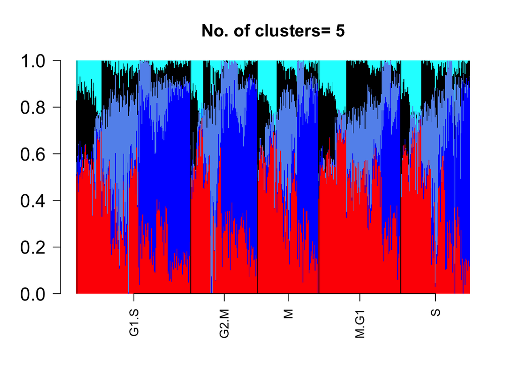

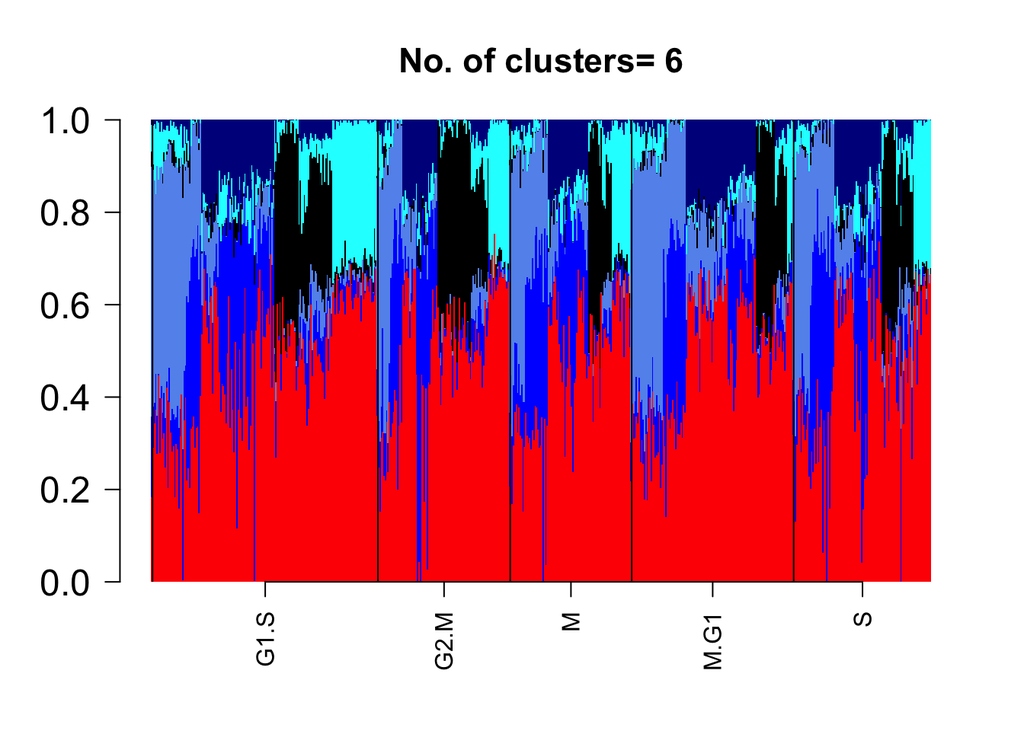

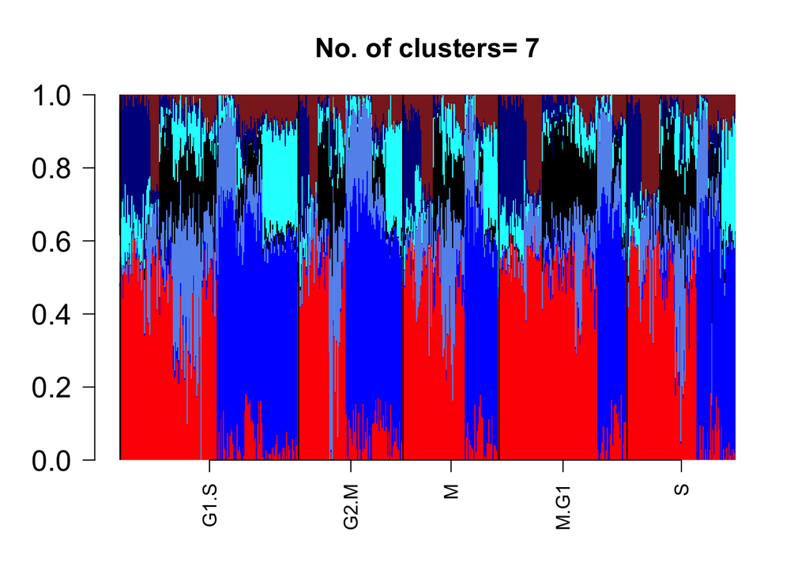

## Individual effects (molecules)

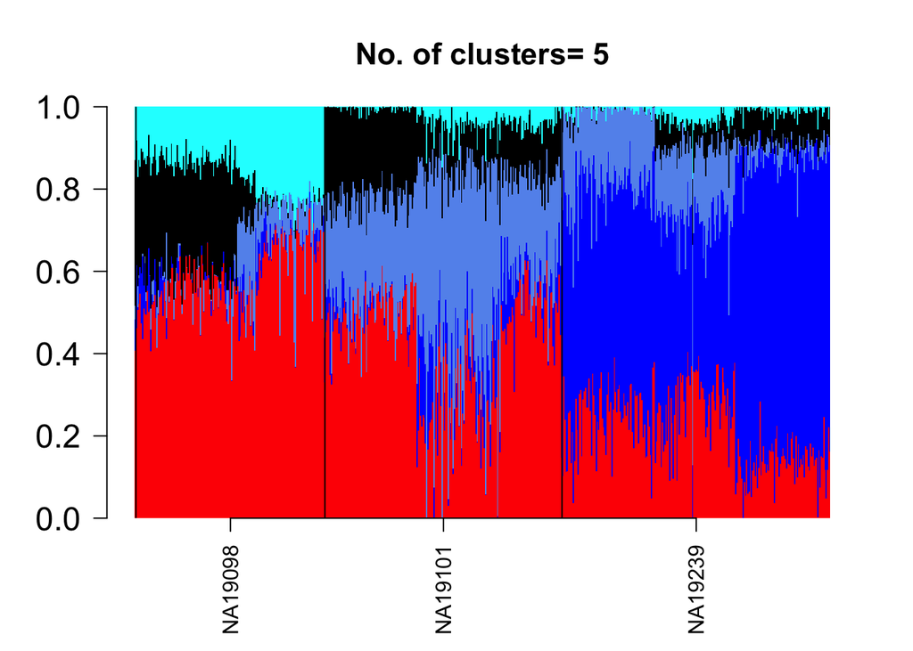

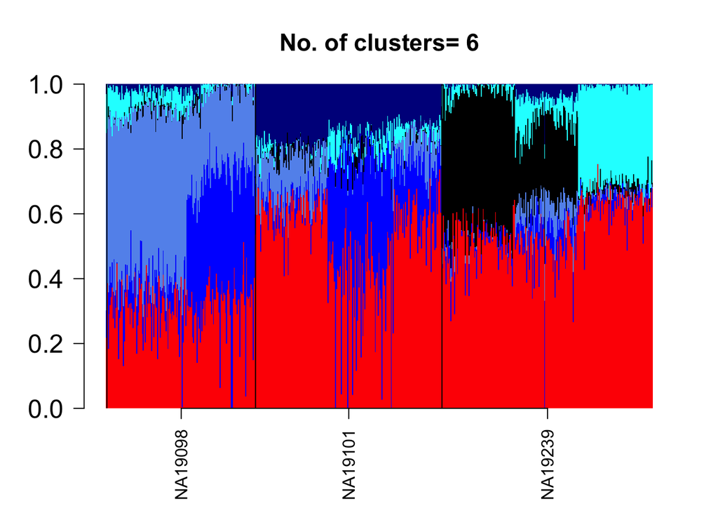

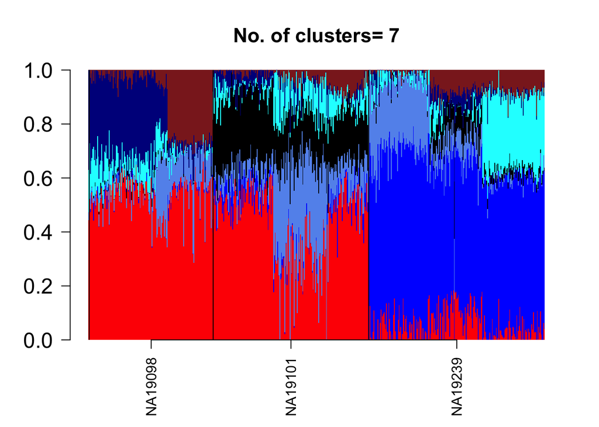

## Batch effects (molecules)

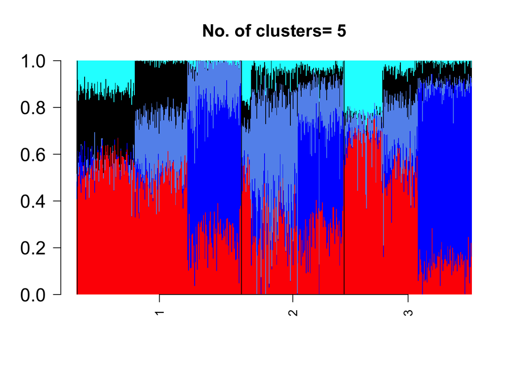

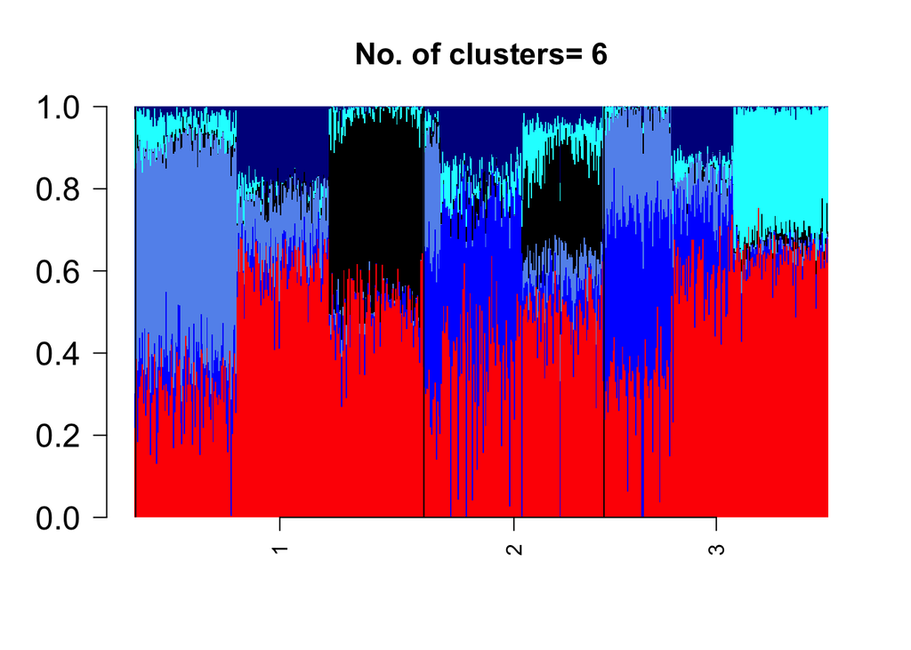

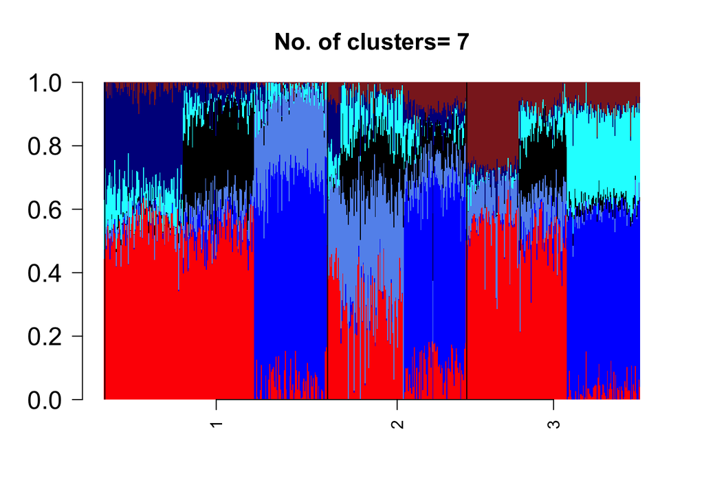

## Well effect (molecules)

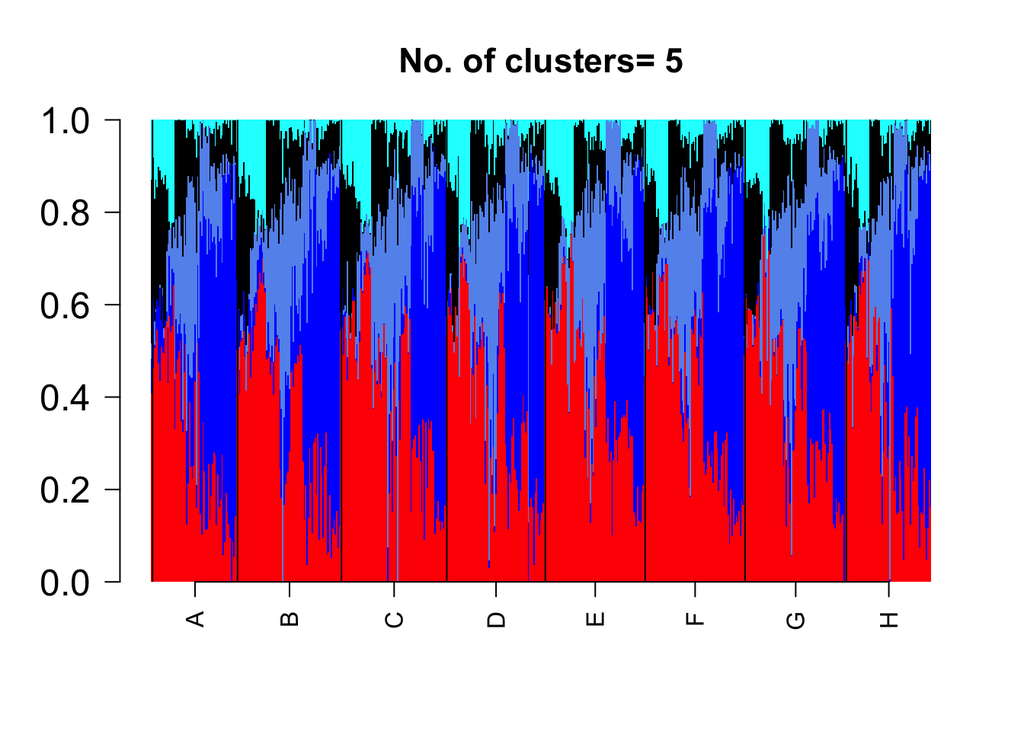

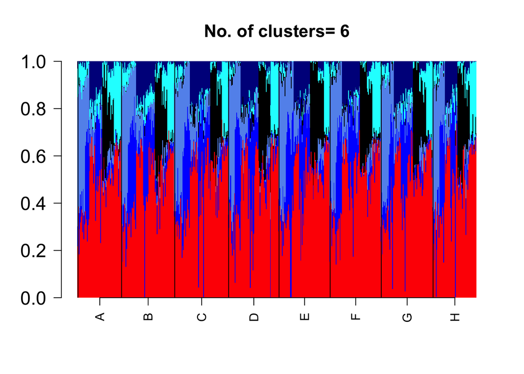

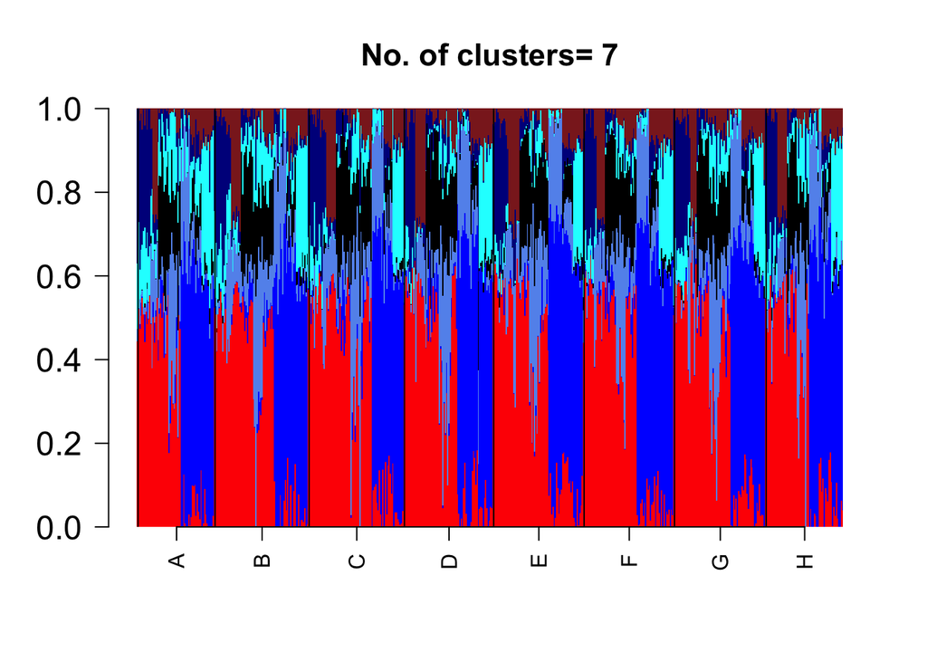